# Data Structures: Data Frames

Enrico Toffalini

### A type of data structure you are already familiar with

[figure not shown]

### A type of data structure you are already familiar with

Here is how I would import it into R (download here), and display the first few rows:

```r
library(readxl)
df = data.frame(read_excel("data/Courses40Cycle.xlsx"))
head(df)
```

```
  Year TypeOfCourse                                                  Title
1    1  METHODOLOGY CURRENT ISSUES IN STATISTICAL INFERENCE FOR PSYCHOLOGY
2    1  METHODOLOGY               LINEAR AND MIXED EFFECT MODELS WITH SPSS
3    1  METHODOLOGY                 BASICS OF STATISTICAL INFERENCE WITH R
4    1  PROGRAMMING                           BASICS OF R FOR DATA SCIENCE
5    1  METHODOLOGY                              PSYCHOLOGICAL MEASUREMENT
6    1  METHODOLOGY                              POWER AND DESIGN ANALYSIS
               Teacher Hours ECTS MandatoryAttendance DeliveryMethod Language
1 MASSIMILIANO PASTORE    10    2                 YES      IN PERSON  ENGLISH
2         JEFF KIESNER    15    3                  NO      IN PERSON  ENGLISH
3     UMBERTO GRANZIOL    20    4                 YES      IN PERSON  ENGLISH
4     ENRICO TOFFALINI    10    2                 YES      IN PERSON  ENGLISH
5      LUCA STEFANUTTI    15    3                 YES      IN PERSON  ENGLISH
6      GIANMARCO ALTOE     5    1                 YES      IN PERSON  ENGLISH
```

### Dataframes as collections of vectors

In fact, **dataframes** are just collections (lists) of **vectors of different types**, all with the same length. Each column in a dataframe is a vector (a variable):

```r
head(df$Teacher)
```

```
[1] "MASSIMILIANO PASTORE" "JEFF KIESNER"         "UMBERTO GRANZIOL"
[4] "ENRICO TOFFALINI"     "LUCA STEFANUTTI"      "GIANMARCO ALTOE"
```

```r
head(df$Hours)
```

```
[1] 10 15 20 10 15  5
```

### Basic Functions on Dataframes

To know the names of all variables in a dataframe, use the **`names()`** function:

```r
names(df)
```

```
[1] "Year"                "TypeOfCourse"        "Title"
[4] "Teacher"             "Hours"               "ECTS"
[7] "MandatoryAttendance" "DeliveryMethod"      "Language"
```

Use the **`dim()`** function to view the dimensions of a dataframe:

```r
# first value is number of rows, second is number of columns (variables)
dim(df)
```

```
[1] 28  9
```

Alternatively, you can use **`nrow()`** and **`ncol()`**:

```r
nrow(df) # number of rows
```

```
[1] 28
```

```r
ncol(df) # number of columns
```

```
[1] 9
```

### Basic Functions on Dataframes

The **`str()`** function provides a quick overview of the structure of a dataframe, including its dimensions, variables, their data types, and the first few observations:

```r
str(df)
```

```
'data.frame':   28 obs. of  9 variables:
 $ Year               : chr  "1" "1" "1" "1" ...
 $ TypeOfCourse       : chr  "METHODOLOGY" "METHODOLOGY" "METHODOLOGY" "PROGRAMMING" ...
 $ Title              : chr  "CURRENT ISSUES IN STATISTICAL INFERENCE FOR PSYCHOLOGY" "LINEAR AND MIXED EFFECT MODELS WITH SPSS" "BASICS OF STATISTICAL INFERENCE WITH R" "BASICS OF R FOR DATA SCIENCE" ...
 $ Teacher            : chr  "MASSIMILIANO PASTORE" "JEFF KIESNER" "UMBERTO GRANZIOL" "ENRICO TOFFALINI" ...
 $ Hours              : num  10 15 20 10 15 5 5 5 5 5 ...
 $ ECTS               : num  2 3 4 2 3 1 1 1 1 1 ...
 $ MandatoryAttendance: chr  "YES" "NO" "YES" "YES" ...
 $ DeliveryMethod     : chr  "IN PERSON" "IN PERSON" "IN PERSON" "IN PERSON" ...
 $ Language           : chr  "ENGLISH" "ENGLISH" "ENGLISH" "ENGLISH" ...
```

## Quick overview of a dataframe: `summary()`

**`summary()`** describes each column according to its type. Here are two numeric columns from the course data; try `summary(df)` for all columns:

```r
summary(df[ , c("Hours", "ECTS")])
```

```
     Hours             ECTS
 Min.   : 5.000   Min.   :1.000
 1st Qu.: 5.000   1st Qu.:1.000
 Median :10.000   Median :2.000
 Mean   : 9.286   Mean   :1.857
 3rd Qu.:11.250   3rd Qu.:2.250
 Max.   :20.000   Max.   :4.000
```

**Tip**

In RStudio, **`View(df)`** opens the data viewer: it can be useful for quick inspection without using Excel, but best keep all data transformations code in your R script.

### Accessing Elements in Dataframes

The “**`$`**” (dollar) operator is essential to access variables in a dataframe:

[figure not shown]

### Accessing and Working with Elements in Dataframes

As an exercise, let’s check whether `Hours` is actually always `ECTS*5`

We may use many different, increasingly sophisticated, strategies:

```r
df$Hours / df$ECTS
```

```
 [1] 5 5 5 5 5 5 5 5 5 5 5 5 5 5 5 5 5 5 5 5 5 5 5 5 5 5 5 5
```

```r
(df$Hours / df$ECTS) == 5
```

```
 [1] TRUE TRUE TRUE TRUE TRUE TRUE TRUE TRUE TRUE TRUE TRUE TRUE TRUE TRUE TRUE
[16] TRUE TRUE TRUE TRUE TRUE TRUE TRUE TRUE TRUE TRUE TRUE TRUE TRUE
```

```r
sum((df$Hours / df$ECTS) == 5)
```

```
[1] 28
```

```r
sum((df$Hours / df$ECTS) == 5) == nrow(df)
```

```
[1] TRUE
```

```r
sum((df$Hours / df$ECTS) != 5)
```

```
[1] 0
```

### Accessing and Working with Elements in Dataframes

Variables in a dataframe can be manipulated like any other vector:

```r
log(df$Hours)
```

```
 [1] 2.302585 2.708050 2.995732 2.302585 2.708050 1.609438 1.609438 1.609438
 [9] 1.609438 1.609438 2.302585 2.302585 1.609438 1.609438 2.302585 2.302585
[17] 2.708050 2.995732 1.609438 2.708050 1.609438 2.302585 1.609438 1.609438
[25] 2.302585 2.708050 1.609438 1.609438
```

Also, new variables can easily be created and added at any time:

```r
df$newVar = log(df$Hours)
names(df)
```

```
 [1] "Year"                "TypeOfCourse"        "Title"
 [4] "Teacher"             "Hours"               "ECTS"
 [7] "MandatoryAttendance" "DeliveryMethod"      "Language"
[10] "newVar"
```

```r
head(df$newVar)
```

```
[1] 2.302585 2.708050 2.995732 2.302585 2.708050 1.609438
```

### Indexing Elements in a Dataframe

In addition to using the “**`$`**” (dollar) operator, you can directly access a variable of a dataframe using **indexing** with **square brackets `[]`**:

```r
df[ , "Hours"]
```

```
 [1] 10 15 20 10 15  5  5  5  5  5 10 10  5  5 10 10 15 20  5 15  5 10  5  5 10
[26] 15  5  5
```

Notice the comma “**`,`**” above.

Unlike vectors, dataframes must be indexed by **both row and column**. In the example above, we’re specifying only the desired column (`"Hours"`), leaving the row index blank before the comma **`,`**. This selects all rows for the column named `"Hours"`. Remember that a blank index means “all”. Importantly, the “**`,`**” must always be there when indexing dataframes!

### Indexing Elements in a Dataframe - Examples

```r
df[ 1 , "Hours"]
```

```
[1] 10
```

```r
df[ 1:5 , "Hours"]
```

```
[1] 10 15 20 10 15
```

```r
df[ 1 , c("Teacher","Hours","TypeOfCourse")]
```

```
               Teacher Hours TypeOfCourse
1 MASSIMILIANO PASTORE    10  METHODOLOGY
```

```r
df[ 1:5 , c("Teacher","Hours","TypeOfCourse")]
```

```
               Teacher Hours TypeOfCourse
1 MASSIMILIANO PASTORE    10  METHODOLOGY
2         JEFF KIESNER    15  METHODOLOGY
3     UMBERTO GRANZIOL    20  METHODOLOGY
4     ENRICO TOFFALINI    10  PROGRAMMING
5      LUCA STEFANUTTI    15  METHODOLOGY
```

```r
df[ 1 , c(4, 5, 2)]
```

```
               Teacher Hours TypeOfCourse
1 MASSIMILIANO PASTORE    10  METHODOLOGY
```

### Indexing and Modifying Elements in a Dataframe

Editing/modifying elements in a dataframe is similar to what you do with vectors

```r
dx = data.frame(name = letters[1:10],
                score = rnorm(10))
dx
```

```
   name        score
1     a  1.262954285
2     b -0.326233361
3     c  1.329799263
4     d  1.272429321
5     e  0.414641434
6     f -1.539950042
7     g -0.928567035
8     h -0.294720447
9     i -0.005767173
10    j  2.404653389
```

```r
# Replace some elements with 'NA'
dx[3:5, "score"] = NA
dx
```

```
   name        score
1     a  1.262954285
2     b -0.326233361
3     c           NA
4     d           NA
5     e           NA
6     f -1.539950042
7     g -0.928567035
8     h -0.294720447
9     i -0.005767173
10    j  2.404653389
```

### Indexing and Modifying Elements in a Dataframe

Editing/modifying elements in a dataframe is similar to what you do with vectors

```r
dx = data.frame(name = letters[1:10],
                score = rnorm(10))
dx
```

```
   name        score
1     a  1.262954285
2     b -0.326233361
3     c  1.329799263
4     d  1.272429321
5     e  0.414641434
6     f -1.539950042
7     g -0.928567035
8     h -0.294720447
9     i -0.005767173
10    j  2.404653389
```

```r
# Multiply all elements by 10
dx$score = dx$score * 10
dx
```

```
   name        score
1     a  12.62954285
2     b  -3.26233361
3     c  13.29799263
4     d  12.72429321
5     e   4.14641434
6     f -15.39950042
7     g  -9.28567035
8     h  -2.94720447
9     i  -0.05767173
10    j  24.04653389
```

### Indexing and Modifying Elements in a Dataframe

Editing/modifying elements in a dataframe is similar to what you do with vectors

```r
dx = data.frame(name = letters[1:10],
                score = rnorm(10))
dx
```

```
   name        score
1     a  1.262954285
2     b -0.326233361
3     c  1.329799263
4     d  1.272429321
5     e  0.414641434
6     f -1.539950042
7     g -0.928567035
8     h -0.294720447
9     i -0.005767173
10    j  2.404653389
```

```r
# Linearly transform all elements
dx$score = round( 100 + dx$score * 15 )
dx
```

```
   name score
1     a   119
2     b    95
3     c   120
4     d   119
5     e   106
6     f    77
7     g    86
8     h    96
9     i   100
10    j   136
```

### Indexing and Modifying Elements in a Dataframe

**Assigning a single value** to a column replaces the value for all rows (this is unlike vectors)

```r
dx = data.frame(name = letters[1:10],
                score = rnorm(10))
dx
```

```
   name        score
1     a  1.262954285
2     b -0.326233361
3     c  1.329799263
4     d  1.272429321
5     e  0.414641434
6     f -1.539950042
7     g -0.928567035
8     h -0.294720447
9     i -0.005767173
10    j  2.404653389
```

```r
# Replace all elements with a constant
dx$score = 3
dx
```

```
   name score
1     a     3
2     b     3
3     c     3
4     d     3
5     e     3
6     f     3
7     g     3
8     h     3
9     i     3
10    j     3
```

### Indexing Dataframes by Logical Conditions

Just like for vectors, you can use **logical conditions** for indexing a dataframe.

How do you extract **only the rows** related to `"MASSIMILIANO PASTORE"`?

```r
head(df[ , c("Teacher", "Hours", "TypeOfCourse")])
```

```
               Teacher Hours TypeOfCourse
1 MASSIMILIANO PASTORE    10  METHODOLOGY
2         JEFF KIESNER    15  METHODOLOGY
3     UMBERTO GRANZIOL    20  METHODOLOGY
4     ENRICO TOFFALINI    10  PROGRAMMING
5      LUCA STEFANUTTI    15  METHODOLOGY
6      GIANMARCO ALTOE     5  METHODOLOGY
```

### Indexing Dataframes by Logical Conditions

Just like for vectors, you can use **logical conditions** for indexing a dataframe.

Let’s consider this logical condition:

```r
df$Teacher == "MASSIMILIANO PASTORE"
```

```
 [1]  TRUE FALSE FALSE FALSE FALSE FALSE FALSE FALSE FALSE FALSE FALSE FALSE
[13] FALSE FALSE FALSE  TRUE FALSE FALSE FALSE FALSE FALSE FALSE FALSE FALSE
[25]  TRUE FALSE FALSE FALSE
```

Let’s extract matching rows and two columns (leave the column index blank for all columns):

```r
df[df$Teacher == "MASSIMILIANO PASTORE", c("Teacher", "Hours")]
```

```
                Teacher Hours
1  MASSIMILIANO PASTORE    10
16 MASSIMILIANO PASTORE    10
25 MASSIMILIANO PASTORE    10
```

### Subset

The base function **`subset()`** can also be used as an alternative to indexing

```r
subset(df, Teacher == "MASSIMILIANO PASTORE", select=c("Teacher","Hours","TypeOfCourse"))
```

```
                Teacher Hours TypeOfCourse
1  MASSIMILIANO PASTORE    10  METHODOLOGY
16 MASSIMILIANO PASTORE    10  METHODOLOGY
25 MASSIMILIANO PASTORE    10  METHODOLOGY
```

```r
df[df$Teacher == "MASSIMILIANO PASTORE" , c("Teacher","Hours","TypeOfCourse")]
```

```
                Teacher Hours TypeOfCourse
1  MASSIMILIANO PASTORE    10  METHODOLOGY
16 MASSIMILIANO PASTORE    10  METHODOLOGY
25 MASSIMILIANO PASTORE    10  METHODOLOGY
```

Indexing with **`[]`** makes the row and column selection explicit and uses the same logic as vectors and matrices. It also transfers well to other programming languages (e.g., **Python**). Choose the form that makes your code clearest.

### Indexing Elements in a Dataframe - A Summary

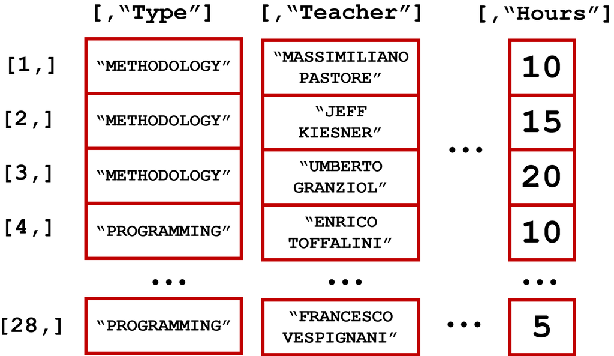

## Matching many values: `%in%`

**`%in%`** asks whether each value matches *any* value in a given vector:

```r
teachers = c("MASSIMILIANO PASTORE", "ENRICO TOFFALINI")
df[df$Teacher %in% teachers, c("Title", "Hours", "ECTS", "MandatoryAttendance")]
```

```
                                                    Title Hours ECTS
1  CURRENT ISSUES IN STATISTICAL INFERENCE FOR PSYCHOLOGY    10    2
4                            BASICS OF R FOR DATA SCIENCE    10    2
12                      BASICS OF PYTHON FOR DATA SCIENCE    10    2
16       BAYESIAN DATA ANALYSIS IN PSYCHOLOGICAL RESEARCH    10    2
25               DATA SIMULATION IN PSYCHOLOGICAL STUDIES    10    2
   MandatoryAttendance
1                  YES
4                  YES
12                  NO
16                  NO
25                  NO
```

Use **`!(df$Teacher %in% teachers)`** to select everyone else.

## `unique()` and `which()`

**`unique()`** returns the distinct values  
**`which()`** returns the positions where a condition is `TRUE`:

```r
unique(df$TypeOfCourse)
```

```
[1] "METHODOLOGY"     "PROGRAMMING"     "SOFT SKILLS"     "THEMATIC COURSE"
```

```r
which(df$Hours > 15)
```

```
[1]  3 18
```

```r
which.max(df$Hours)
```

```
[1] 3
```

**Tip**

`which.max()` gives the position of the **first maximum**. These positions can go straight into the row index: `df[which(df$Hours > 15), ]`.

## Sorting: `sort()` and `order()`

- **`sort()`** rearranges the values in a vector:

```r
sort(df$Hours)
```

```
 [1]  5  5  5  5  5  5  5  5  5  5  5  5  5 10 10 10 10 10 10 10 10 15 15 15 15
[26] 15 20 20
```

```r
sort(df$Hours, decreasing=TRUE)
```

```
 [1] 20 20 15 15 15 15 15 10 10 10 10 10 10 10 10  5  5  5  5  5  5  5  5  5  5
[26]  5  5  5
```

- **`order()`** returns positions, it’s useful to **rearrange rows** of a data frame by one or more variables:

```r
# order data frame by "Hours"
df[order(df$Hours), ]
```

```r
# order alphabetically by course type, then by hours from highest to lowest
df[order(df$TypeOfCourse, -df$Hours), ]
```

### Combine Two Dataframes Using `rbind()`

Imagine you have two datasets collected by two students, each including different participants:

```r
df1
```

```
  subjName age accuracy
1    Julie  12     0.92
2    Tommy  10     0.78
3     Phil  10     0.85
```

```r
df2
```

```
  subjName age accuracy
1    Amber   9     0.87
2      Max  13     0.90
```

Our goal is to get one single dataset including all participants’ data for the final analysis. Of course, you could combine these files manually outside R (e.g., in Excel). However, it’s simpler and more efficient to do this directly in R using `rbind()`

### Combine Two Dataframes Using `rbind()`

```r
dfTotal = rbind(df1, df2)

dfTotal
```

```
  subjName age accuracy
1    Julie  12     0.92
2    Tommy  10     0.78
3     Phil  10     0.85
4    Amber   9     0.87
5      Max  13     0.90
```

**Important**: for `rbind()` to work, the two to-be-combined dataframes must:

- have the **exact same number of columns**;
- have **identical column names** (remember that R is case-sensitive).

### Merge Two Dataframes Using `merge()`

Another frequent case is having data collected from the **same participants** across **different dataframes**, and having to analyze all information together:

```r
df1
```

```
  subjName age
1    Julie  12
2    Amber   9
3    Tommy  10
4     Phil  10
```

```r
df2
```

```
  subjName accuracy time
1    Julie     0.92 1203
2    Tommy     0.78 3302
3     Phil     0.85  994
4    Amber     0.87 1163
```

### Merge Two Dataframes Using `merge()`

You can merge the two dataframes into a single, comprehensive dataframe:

```r
dfTotal = merge(df1, df2, by="subjName")

dfTotal
```

```
  subjName age accuracy time
1    Amber   9     0.87 1163
2    Julie  12     0.92 1203
3     Phil  10     0.85  994
4    Tommy  10     0.78 3302
```

**Tip**

**Important**: **`merge()`** will work even if some or even all values that should be used for merging do not match… but in that case some or all of the data will be lost

### `merge()` keeping everything: `all=TRUE`

Let’s reuse the participants from the previous example, but suppose **Amber is missing from the second file**:

```r
df2partial = df2[df2$subjName != "Amber", ]
merge(df1, df2partial, by="subjName", all=TRUE)
```

```
  subjName age accuracy time
1    Amber   9       NA   NA
2    Julie  12     0.92 1203
3     Phil  10     0.85  994
4    Tommy  10     0.78 3302
```

**`all=TRUE`** keeps names found in either file. Missing information is indicated with the special placeholder **`NA`** (the default merge would lose Amber’s row here)

### Row-wise scores: `rowSums()` and `rowMeans()`

```r
wisc = read.csv("data/wisc.csv")
wisc$tot = rowSums(wisc, na.rm=TRUE)
head(wisc)
```

```
  BD SI DS PCn CD VC LN MR CO SS tot
1 13 10  7  10 15  7 10 16  8 13 109
2  7 11  6   8 13 10  9  5  9 14  92
3 12  6  5   7  9  7  7  6  9  8  76
4  8  7  9  11  1  5  7  6  8  4  66
5 12 13  8  10 10 10  9 11 13 12 108
6 13 17 13   7 10 19 13 10 15 13 130
```

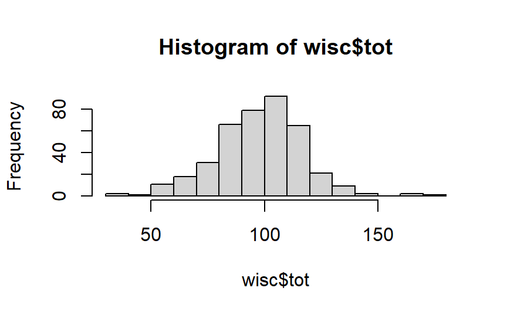

```r
hist(wisc$tot)
```

⚠️ With **`na.rm=TRUE`** missing items lower the total sum in a misleading way (e.g., an entirely missing row gives **0**). **`rowMeans()`** may be useful for comparable totals when removing the **`NA`s**, but it still needs at least one observation (all missing gives **`NaN`**)

### Summaries by group: `aggregate()`

**`Hours ~ TypeOfCourse`**: summarize hours separately for each course type.

```r
aggregate(Hours ~ TypeOfCourse, FUN=mean, data=df)
```

```
     TypeOfCourse  Hours
1     METHODOLOGY 10.625
2     PROGRAMMING  8.750
3     SOFT SKILLS  7.500
4 THEMATIC COURSE  5.000
```

For several numeric columns, combine them with **`cbind()`**:

```r
aggregate(cbind(Hours, ECTS) ~ TypeOfCourse, FUN=sum, data=df)
```

```
     TypeOfCourse Hours ECTS
1     METHODOLOGY   170   34
2     PROGRAMMING    35    7
3     SOFT SKILLS    45    9
4 THEMATIC COURSE    10    2
```

### Summaries by group: selected columns

In a formula, **`.`** means “all the other columns”. Select only the columns you intend to summarize:

```r
aggregate(. ~ TypeOfCourse, FUN=mean,
          data=df[ , c("TypeOfCourse", "Hours", "ECTS")])
```

```
     TypeOfCourse  Hours  ECTS
1     METHODOLOGY 10.625 2.125
2     PROGRAMMING  8.750 1.750
3     SOFT SKILLS  7.500 1.500
4 THEMATIC COURSE  5.000 1.000
```

The same **`y ~ group`** notation can provide a quick graphical check:

```r
boxplot(Hours ~ TypeOfCourse, data=df)
```

Try this plot in your console. Proper figure design is covered in the ggplot2 course.

### Contingency Tables

The **`table()`** function, which counts frequencies, can also be used on dataframes. Importantly, it can also create **contingency tables** when applied to multiple variables at once

```r
table(df$Hours) # just counts frequencies
```

```
 5 10 15 20
13  8  5  2
```

```r
table(df$TypeOfCourse, df$Hours) # creates a contingency table
```

```
                  5 10 15 20
  METHODOLOGY     6  4  4  2
  PROGRAMMING     1  3  0  0
  SOFT SKILLS     4  1  1  0
  THEMATIC COURSE 2  0  0  0
```

## Wide vs long format

The **same three participants**, measured longitudinally:

**Wide format**: one row per participant

| id | T0 | T1 | T2 |
| --- | --- | --- | --- |
| a | 10 | 11 | 13 |
| b | 12 | 14 | 15 |
| c | 9 | 9 | 10 |
| … |  |  |  |

**Long format**: one row per observation

| id | time | score |
| --- | --- | --- |
| a | T0 | 10 |
| b | T0 | 12 |
| c | T0 | 9 |
| a | T1 | 11 |
| b | T1 | 14 |
| c | T1 | 9 |
| a | T2 | 13 |
| b | T2 | 15 |
| c | T2 | 10 |
| … |  |  |

## wide → long with `reshape()`

**`reshape()`** is base R; its arguments may take some practice…

```r
dfWide = ...
```

| id | T0 | T1 | T2 |
| --- | --- | --- | --- |
| a | 10 | 11 | 13 |
| b | 12 | 14 | 15 |
| c | 9 | 9 | 10 |

```r
dfLong = reshape(dfWide,
                 direction="long",
                 varying=c("T0", "T1", "T2"),
                 v.names="score",
                 timevar="time",
                 times=c("T0", "T1", "T2"),
                 idvar="id")
```

```
     id time score
a.T0  a   T0    10
b.T0  b   T0    12
c.T0  c   T0     9
a.T1  a   T1    11
b.T1  b   T1    14
c.T1  c   T1     9
a.T2  a   T2    13
b.T2  b   T2    15
c.T2  c   T2    10
```

## The same with tidyr

The **tidyr** package provides an easier to remember function

```r
library(tidyr)
```

wide → long

```r
dfLong = pivot_longer(dfWide,
                      cols=c(T0,T1,T2),
                      names_to="time",
                      values_to="score")
```

long → wide

```r
dfWide = pivot_wider(dfLong,
            names_from=time,
            values_from=score)
```

### The convenience of the long format

**SUMMARIZING**: With time in one column, summarizing time points is easier

```r
aggregate(score ~ time, FUN=mean, data=dfLong)
```

```
  time    score
1   T0 10.33333
2   T1 11.33333
3   T2 12.66667
```

**STATISTICAL MODELING**: e.g., in mixed-models long formats let you identify repeated observations within clustering factor

```r
lme4::lmer(score ~ time + (1|id), data=dfLong)
```

**DATA VISUALIZATION**: Long data are also useful for **`ggplot2`**, where you want to have all observations for the same variable in a same column/vector

## The pipe `|>`

in R 4.1 and later, “**`|>`**” passes a result to the first argument of the next function

Classical nested functions style

```r
x = df$Hours
round(sqrt(mean(x)), 2)
```

```
[1] 3.05
```

Pipelined

```r
x |> mean() |> sqrt() |> round(2)
```

```
[1] 3.05
```

They do the same, but the right expression may be easier to read (left to right)

**Tip**

You may also encounter **`%>%`** from magrittr/dplyr: it works similarly in the `tidyverse` package suite.